# INFSCI 2595 Final

Part Ia: Prediction targets (`outcome`)

Ben Stein

4/27/2022

# About this document

In this document, I perform exploratory data analysis on the `outcome` variable, which is our prediction target for the classification portions of the project.

# Setup

## Libraries and tools

```r
library(tidyverse)
source("./tools.R")
```

## Data

```r
df <- load_project_data(list(convert_data_types = TRUE, response_to_log = FALSE))
df %>% glimpse()
```

```
## Rows: 677
## Columns: 38
## $ rowid    <dbl> 1, 3, 4, 5, 8, 9, 11, 14, 15, 16, 17, 18, 19, 22, 24, 25, 27,~
## $ region   <fct> XX, XX, XX, XX, XX, XX, XX, XX, XX, XX, XX, XX, XX, XX, XX, X~
## $ customer <fct> B, B, B, B, B, B, B, B, B, B, B, B, B, B, B, B, B, B, B, B, B~
## $ xb_01    <dbl> 4.000000, 1.000000, 2.000000, 2.520000, 2.548387, 3.071429, 3~
## $ xb_02    <dbl> 4, 1, 2, 11, 6, 6, 10, 12, 9, 10, 8, 10, 10, 8, 6, 10, 13, 10~
## $ xb_03    <dbl> 4, 1, 2, -6, -1, 1, -4, -4, -2, -4, -2, -2, -2, -4, 1, -4, -3~
## $ xn_01    <dbl> 3.0000000, 2.0000000, 2.0000000, 1.5333333, 0.8387097, 1.8571~
## $ xn_02    <dbl> 3, 2, 4, 9, 3, 8, 6, 10, 10, 4, 6, 8, 9, 5, 7, 12, 12, 6, 6, ~
## $ xn_03    <dbl> 3, 2, 0, -3, -4, -2, -5, -6, -3, -5, -3, -6, -4, -3, 0, -5, -~
## $ xa_01    <dbl> 12.000000, 3.000000, 9.000000, 7.080000, 6.451613, 6.857143, ~
## $ xa_02    <dbl> 12, 3, 9, 29, 17, 18, 24, 27, 20, 19, 15, 24, 24, 15, 14, 26,~
## $ xa_03    <dbl> 12, 3, 9, -7, -2, 2, -9, -5, -3, -3, -1, 1, -2, -3, 3, -4, -5~
## $ xb_04    <dbl> 1.3333333, 1.0000000, 1.0000000, 0.8950476, 1.2247312, 1.1857~
```

[output cut: 25 more lines]

# Exploratory Data Analysis

The `outcome` is a binary variable which describes whether a given product failed to meet its sales goal (i.e. a value of `"event"` indicates that it **did not** meet its sales goal).

## The variable itself

```r
df %>%
  select(outcome) %>%
  summary()
```

```
##       outcome
##  event    :127
##  non_event:550
```

```r
df %>%
  mutate(outcome_logical = ifelse(outcome == "event", 1, 0)) %>%
  select(outcome_logical) %>%
  summary()
```

```
##  outcome_logical
##  Min.   :0.0000
##  1st Qu.:0.0000
##  Median :0.0000
##  Mean   :0.1876
##  3rd Qu.:0.0000
##  Max.   :1.0000
```

The `event` outcome is relatively rare in the dataset (127 times out of 677 trials, or with about **0.188** probability). Good for PPG! Or maybe they’re not setting their goals ambitiously enough…

## In relation to categorical predictors

Let’s see if the distribution is dramatically different when we segment the data using the categorical predictors of `region` and `customer`.

### Region

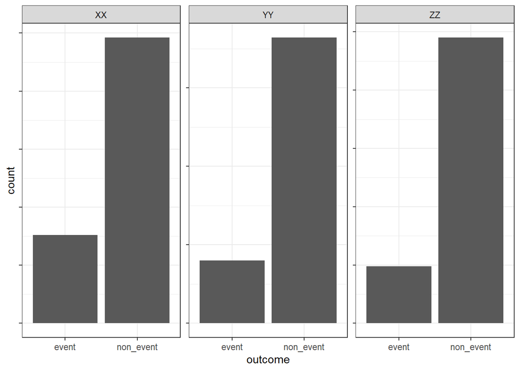

```r
df %>%
  select(region, outcome) %>%
  ggplot(mapping = aes(x = outcome)) +
  geom_histogram(stat = "count") +
  facet_wrap(~region, scales = "free") +
  theme_bw() +
  theme(axis.text.y = element_blank())
```

It seems as though the event occurs in relatively the same proportion across regions.

### Customer

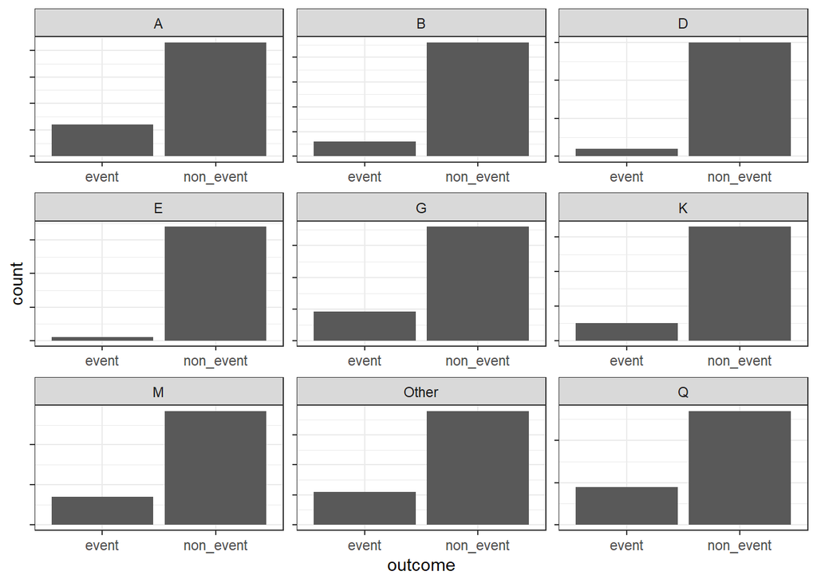

```r
df %>%
  select(customer, outcome) %>%
  ggplot(mapping = aes(x = outcome)) +
  geom_histogram(stat = "count") +
  facet_wrap(~customer, scales = "free") +
  theme_bw() +
  theme(axis.text.y = element_blank())
```

```r
df %>%
  select(customer, outcome) %>%
  group_by(customer) %>%
  summarize(
    outcome = mean(ifelse(outcome == "event", 1, 0))
  )
```

```
## # A tibble: 9 x 2
##   customer outcome
##   <fct>      <dbl>
## 1 A         0.218
## 2 B         0.115
## 3 D         0.0625
## 4 E         0.0286
## 5 G         0.204
## 6 K         0.132
## 7 M         0.197
## 8 Other     0.224
## 9 Q         0.25
```